# Figure 6 mapping MMA distribution SA3

Author

Alexander W. Gofton & Emily Smith

Published

March 13, 2026

## Setup

Load required packages for data manipulation, spatial data handling, and polygon smoothing.

```r
library(tidyverse)
library(sf)
library(smoothr)
```

# Load and Wrangle Data

Import SA3-level case rate shapefiles, Australian state boundaries, significant urban area boundaries, and the Ixodes holocyclus distribution polyline, then smooth the tick distribution line using spline interpolation.

```r
# Load shape files
sa3 <- read_sf("data/SA3_case_data.shp")

# Downloaded from ABS website
states <- read_sf(
  "ABS_shapefiles/STATES_2021_AUST_GDA2020/STE_2021_AUST_GDA2020.shp"
)

# Downloaded from ABS website
sig_urban_areas <- read_sf(
  "ABS_shapefiles/SUA_2021_AUST_GDA2020/SUA_2021_AUST_GDA2020.shp"
)

# Calculate centroids for each significant urban area
#Find center of cities
sig_urban_points <- sig_urban_areas %>%
  mutate(
    centroid = st_centroid(geometry),
    cent_long = st_coordinates(centroid)[, "X"],
    cent_lat = st_coordinates(centroid)[, "Y"]
  )

# Load I.hol dist line
Ihol_dist_line <- st_read("data/holocyclus_distribution_polyline.geojson") %>%
  filter(st_geometry_type(.) == "LINESTRING")

# Spline smoothing
Ihol_dist_line_smooth <- Ihol_dist_line %>%
  smooth(method = "spline")
```

# Filtering Significant Urban Area Labels

Select a subset of significant urban areas along the eastern Australian seaboard to display as labelled reference points on the maps.

```r
sig_urban_points <- sig_urban_points %>%
  filter(
    SUA_NAME21 %in%
      c(
        "Cairns",
        "Townsville",
        "Mackay",
        "Rockhampton",
        "Emerald",
        "Gladstone",
        "Bundaberg",
        "Maryborough",
        "Sunshine Coast",
        "Kingaroy",
        "Brisbane",
        "Toowoomba",
        "Gold Coast",
        "Lismore",
        "Byron Bay",
        "Grafton",
        "Coffs Harbour",
        "Armidale",
        "Kempsey",
        "Port Macquarie",
        "Taree",
        "Tamworth",
        "Newcastle",
        "Mudgee",
        "Dubbo",
        "Sydney",
        "Orange",
        "Wolongong",
        "Goulburn",
        "Canberra - Queanbeyan",
        "Wagga Wagga",
        "Griffith",
        "Batemans Bay",
        "Bairnsdale",
        "Melbourne",
        "Sale",
        "Ulladulla"
      )
  )
```

# Categorise Case Rates for Mapping

Classify SA3 regions into ordinal case rate categories based on suspected MMA cases per 1M person-years, using breakpoints derived from Jenks natural breaks and head/tail methodology. Regions with no test data are separated from those with zero cases.

```r
# New categories based on ES's work
# Breaks based on Jenks natural breaks and head/tail methodology

# Function to create cases categories
cases_2_cat <- function(sf_file, cases_col, new_cases_cat_col, test_cols) {
  cases_col <- sym(cases_col) # Capture column names
  new_cases_cat_col <- sym(new_cases_cat_col) # Convert string to symbol

  sf_file %>%
    mutate(
      total_tests = rowSums(across(all_of(test_cols)), na.rm = TRUE),
      !!new_cases_cat_col := case_when(
        total_tests == 0 ~ "No data",
        is.na(!!cases_col) ~ "No data",
        !!cases_col >= 300 ~ ">300 Suspected cases",
        !!cases_col >= 100 ~ "100-299 Suspected cases",
        !!cases_col >= 30 ~ "30-99 Suspected cases",
        !!cases_col >= 10 ~ "10-29 Suspected cases",
        !!cases_col > 0 ~ "<10 Suspected cases",
        !!cases_col == 0 ~ "0 Suspected cases"
      )
    ) %>%
    select(-total_tests) %>%
    mutate(
      !!new_cases_cat_col := factor(
        !!new_cases_cat_col,
        levels = c(
          ">300 Suspected cases",
          "100-299 Suspected cases",
          "30-99 Suspected cases",
          "10-29 Suspected cases",
          "<10 Suspected cases",
          "0 Suspected cases",
          "No data"
        )
      )
    )
}

test_cols <- paste0("t", 14:24)
sa3_cat <- cases_2_cat(sa3, "c1MPPY", "ESCat", test_cols)

write_sf(sa3_cat, "code/static_maps/sa3_cases_ESCat.shp")
```

# Set Colour Scheme

Define a sequential blue colour palette for the choropleth map categories, from dark blue (highest case rates) to near-white (zero cases), with grey for regions with no data.

```r
color_mapping_blue_ES <- c(
  ">300 Suspected cases" = "#08306b",
  "100-299 Suspected cases" = "#08519c",
  "30-99 Suspected cases" = "#4292c6",
  "10-29 Suspected cases" = "#9ecae1",
  "<10 Suspected cases" = "#deebf7",
  "0 Suspected cases" = "#f7f7f7",
  "No data" = "grey90"
)
```

# National Map

Render a full-Australia choropleth map of suspected MMA case rates per SA3 region, with state borders and the Ixodes holocyclus distribution boundary overlaid as a dashed red line.

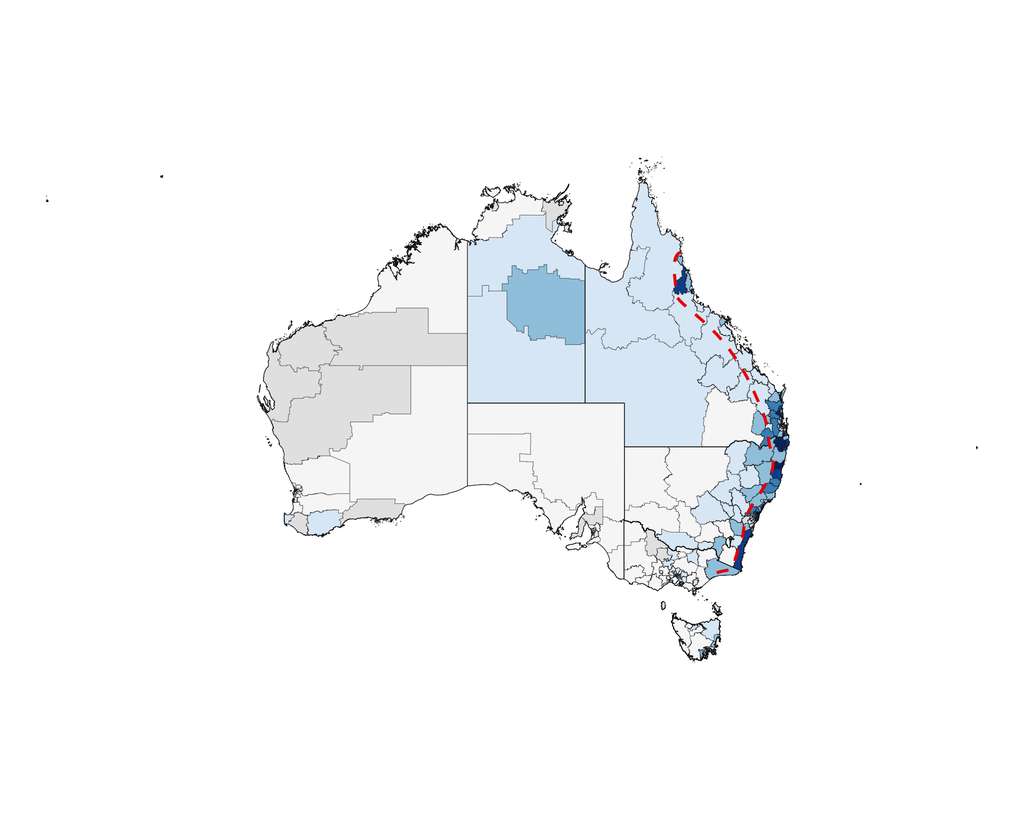

```r
sa3_cat <- read_sf("code/static_maps/sa3_cases_ESCat.shp")

es_map <- ggplot() +
  # Base SA3 map
  geom_sf(data = sa3_cat, aes(fill = ESCat), color = "grey20", size = 0.1) +
  scale_fill_manual(
    values = color_mapping_blue_ES,
    name = "Suspected MMA Cases\nper 1M PPY",
    na.value = "grey90",
    guide = guide_legend(
      title.position = "top",
      title.hjust = 0.5,
      label.position = "right",
      keywidth = 1.5,
      keyheight = 1.5,
      order = 1
    )
  ) +
  # State borders
  geom_sf(data = states, fill = NA, color = "grey10", size = 0.2) +
  coord_sf(
    expand = FALSE,
    xlim = c(113, 154),
    ylim = c(-44, -10),
    clip = "on"
  ) +
  # I. holocyclus distribution overlay
  geom_sf(
    data = Ihol_dist_line_smooth,
    color = "red2",
    size = 1,
    linetype = "dashed"
  ) +
  theme_void() +
  theme(
    legend.position = "none",
    legend.title = element_text(
      size = 12,
      face = "bold",
      margin = margin(b = 10)
    ),
    legend.text = element_text(size = 12)
  ) +
  labs(
    x = "Longitude",
    y = "Latitude"
  )

# Save map
ggsave(
  "plots/Final_Plots/maps/whole_Aus_ES.png",
  es_map,
  height = 30,
  width = 50,
  units = "cm",
  bg = "white",
  dpi = 300
)

ggsave(
  "plots/Final_Plots/maps/whole_Aus_ES.pdf",
  es_map,
  height = 30,
  width = 50,
  units = "cm",
  bg = "white"
)

es_map
```

# East Coast Inset Map

Create a zoomed-in view of the eastern Australian seaboard from Cairns to Melbourne, with city labels and the I. holocyclus distribution line overlay for detailed regional comparison.

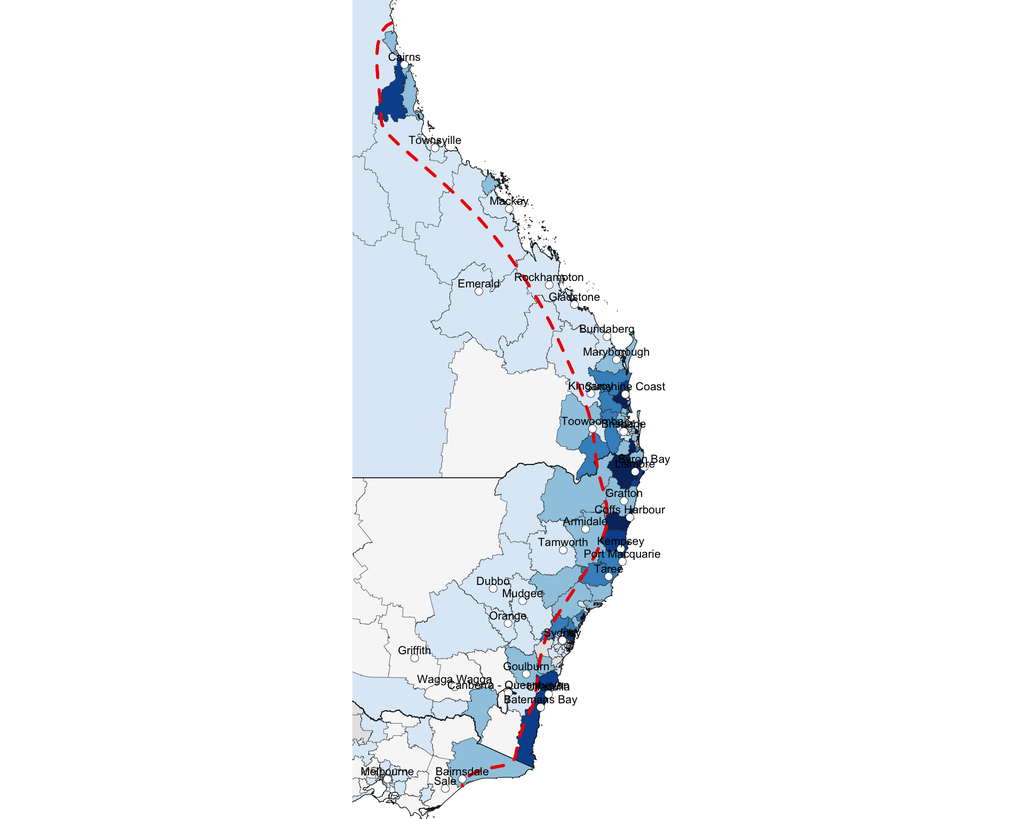

```r
ec_map <- es_map +
  # I. holocyclus distribution overlay
  geom_sf(
    data = Ihol_dist_line_smooth,
    color = "red2",
    size = 1,
    linetype = "dashed",
    lineend = "round"
  ) +
  coord_sf(expand = FALSE, xlim = c(144, 154.5), ylim = c(-39, -15)) +
  geom_point(
    data = sig_urban_points,
    aes(cent_long, cent_lat),
    size = 2.5,
    color = "black",
    fill = "white",
    stroke = 0.2,
    shape = 21
  ) +
  geom_text(
    data = sig_urban_points,
    aes(cent_long, cent_lat, label = SUA_NAME21),
    size = 2.8,
    vjust = -0.5,
    hjust = 0.5,
    color = "black"
  )


# Save map
ggsave(
  "plots/Final_Plots/maps/East_coast_1.png",
  ec_map,
  height = 30,
  width = 50,
  units = "cm",
  bg = "white"
)

ggsave(
  "plots/Final_Plots/maps/East_coast_1.pdf",
  ec_map,
  height = 30,
  width = 50,
  units = "cm",
  bg = "white"
)

ec_map
```